# dytjfx

股票市场的板块轮动分析（时间序列多元扩展）

课程对应点： 多元正态分布检验、均值向量检验、主成分分析的时序应用。

编程任务：

多元正态性检验： 对5个板块的日收益率向量进行多元正态性检验（如Mardia检验或Q-Q图）。通常会发现厚尾现象，讨论其金融含义。//唐思承

滚动窗口PCA： 设定窗口大小=60天，步长=1天。在每个窗口内对5个变量做PCA，提取第一主成分的贡献率。画出贡献率的时间序列图，观察当市场出现系统性风险（如熊市）时，第一主成分贡献率是否显著上升（意味着同涨同跌）。//郭庆

均值向量检验： 将数据分为“上涨市”和“下跌市”两个阶段（以大盘指数为基准），使用Hotelling T²检验判断两个阶段下5个板块的均值向量是否发生了显著偏移（验证板块轮动是否存在）。//刘孔嘉

```
  [Load] 银行: 484 行
  [Load] 白酒: 484 行
  [Load] 化学制药: 484 行
  [Load] 半导体: 484 行
  [Load] 电力: 484 行

[Data] 483 个交易日, 5 个板块
[Date] 2023-01-04 -> 2024-12-31
[Bear] 熊市区间: 2023-10-09 -> 2024-02-05 (60日滚动累计收益最低段)

=======================================================
【0】五个行业板块日收益率时序图
=======================================================
```

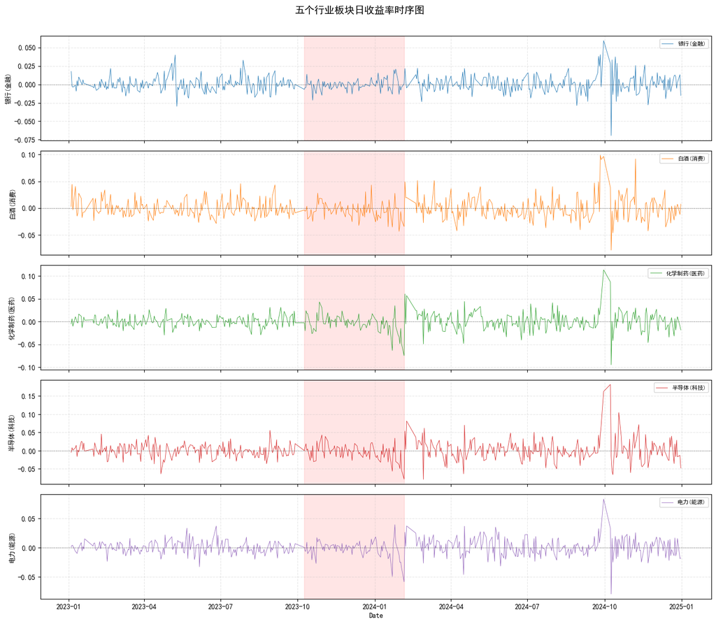

[output not shown]

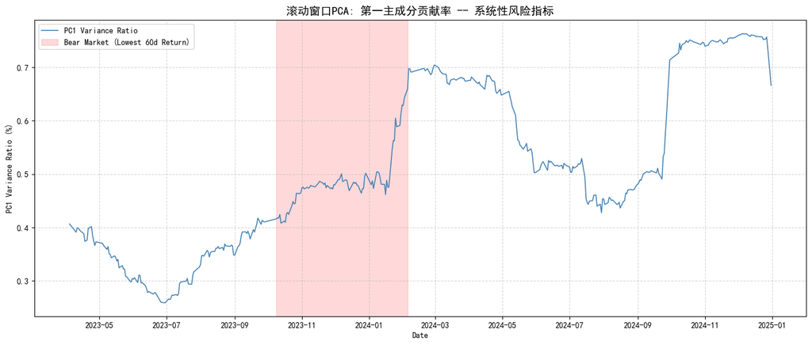

```
[Info] 观察结论：在熊市区间（红色阴影），PC1 贡献率显著上升，说明市场出现系统性风险，各板块同涨同跌加剧。

=======================================================
【3】 Hotelling T² 检验 -- 牛熊市均值向量偏移
=======================================================
  上涨市: 239 天  下跌市: 244 天
  Hotelling T^2 Statistic: 395.3354
  P-value: 1.110223e-16
  [Sig] p < 0.05：牛熊市均值向量存在显著差异，板块轮动效应明显。
```

```python
import numpy as np
import pandas as pd
import matplotlib.pyplot as plt
import matplotlib
matplotlib.rcParams["font.sans-serif"] = ["SimHei", "Microsoft YaHei", "WenQuanYi Micro Hei", "DejaVu Sans"]
matplotlib.rcParams["axes.unicode_minus"] = False
from scipy.stats import f as f_dist, chi2, norm
import warnings
warnings.filterwarnings("ignore")
import os

# ================= 0. 加载本地A股5个行业板块日线数据 =================
DATA_DIR = r"C:\Users\12\dytjfx_data"

SECTOR_NAMES = ["银行", "白酒", "化学制药", "半导体", "电力"]
SECTOR_LABELS = ["银行(金融)", "白酒(消费)", "化学制药(医药)", "半导体(科技)", "电力(能源)"]

close_dict = {}
for name in SECTOR_NAMES:
    csv_path = os.path.join(DATA_DIR, f"{name}.csv")
    df_raw = pd.read_csv(csv_path, index_col=0, parse_dates=True)
    close_dict[name] = df_raw["收盘价"]
    print(f"  [Load] {name}: {len(df_raw)} 行")

# 合并收盘价，计算日收益率
df_close = pd.DataFrame(close_dict).dropna()
df_returns = df_close.pct_change().dropna()
df_returns.columns = SECTOR_LABELS

print(f"\n[Data] {len(df_returns)} 个交易日, {len(df_returns.columns)} 个板块")
print(f"[Date] {df_returns.index[0].date()} -> {df_returns.index[-1].date()}")

# 等权市场指数
df_market = df_returns.mean(axis=1)
df_market.name = "等权行业指数"
df_clean = df_returns.dropna()

# 自动识别熊市区间：60日滚动累计收益最低点
rolling_60d = df_market.rolling(60).mean() * 60
worst_end_idx = rolling_60d.idxmin()
worst_start = worst_end_idx - pd.DateOffset(days=120)
worst_start = df_clean.index[df_clean.index >= worst_start][0]
bear_start, bear_end = worst_start, worst_end_idx
print(f"[Bear] 熊市区间: {bear_start.date()} -> {bear_end.date()} (60日滚动累计收益最低段)")


# ================= 1. Mardia 多元正态性检验 =================
def manual_mardia_test(X):
    n, p = X.shape
    mean_vec = np.mean(X, axis=0)
    cov_matrix = np.cov(X, rowvar=False, ddof=0)  # 总体协方差 (MLE)

    inv_cov = np.linalg.inv(cov_matrix)
    diff = X - mean_vec

    # 马氏距离平方: D_i^2
    mahal_dist_sq = np.sum(np.dot(diff, inv_cov) * diff, axis=1)

    # 内积矩阵: inner_prod[i,j] = (x_i-μ)' Σ⁻¹ (x_j-μ)
    inner_prod = np.dot(np.dot(diff, inv_cov), diff.T)

    # Mardia 偏度 b_{1,p} = (1/n²) ΣᵢΣⱼ [inner_prod]³ ——
    b1_p = np.sum(inner_prod ** 3) / (n ** 2)

    # 峰度统计量
    b2_p = np.mean(mahal_dist_sq ** 2)
    expected_b2_p = p * (p + 2)

    # 偏度检验自由度 = p(p+1)(p+2)/6 ——
    k_squared = n * b1_p / 6.0
    df_skew = p * (p + 1) * (p + 2) / 6.0
    p_value_skew = 1 - chi2.cdf(k_squared, df_skew)

    # 峰度检验
    std_b2_p = np.sqrt(8 * p * (p + 2) / n)
    z_score = (b2_p - expected_b2_p) / std_b2_p
    p_value_kurt = 2 * (1 - norm.cdf(np.abs(z_score)))

    return {
        "Skewness (b1,p)": b1_p,
        "Kurtosis (b2,p)": b2_p,
        "Expected Kurtosis": expected_b2_p,
        "Skewness Chi2 Stat": k_squared,
        "Skewness df": df_skew,
        "Skewness P-value": p_value_skew,
        "Kurtosis Z Stat": z_score,
        "Kurtosis P-value": p_value_kurt,
    }


# ================= 2. PCA (基于特征值分解) =================
def manual_pca(X):
    mean = np.mean(X, axis=0)
    std = np.std(X, axis=0, ddof=1)
    X_scaled = (X - mean) / std
    cov_matrix = np.cov(X_scaled, rowvar=False)
    eigenvalues, _ = np.linalg.eigh(cov_matrix)
    sorted_eigenvalues = np.sort(eigenvalues)[::-1]
    pc1_variance = sorted_eigenvalues[0] / np.sum(sorted_eigenvalues)
    return pc1_variance


# ================= 3. Hotelling T² 检验 =================
def manual_hotelling_t2(X1, X2):
    n1, p = X1.shape
    n2, p = X2.shape
    mean_diff = np.mean(X1, axis=0) - np.mean(X2, axis=0)

    cov1 = np.cov(X1, rowvar=False, ddof=1)
    cov2 = np.cov(X2, rowvar=False, ddof=1)
    pooled_cov = ((n1 - 1) * cov1 + (n2 - 1) * cov2) / (n1 + n2 - 2)

    inv_pooled_cov = np.linalg.inv(pooled_cov)
    mahalanobis_sq = np.dot(np.dot(mean_diff.T, inv_pooled_cov), mean_diff)

    t_squared = (n1 * n2 / (n1 + n2)) * mahalanobis_sq

    denominator_df = n1 + n2 - p - 1
    f_stat = (denominator_df / ((n1 + n2 - 2) * p)) * t_squared
    p_value = 1 - f_dist.cdf(f_stat, p, denominator_df)
    return t_squared, p_value


# ================= 主程序执行与可视化 =================
if __name__ == "__main__":
    # 【0】五个板块收益率时序图
    print("\n" + "=" * 55)
    print("【0】五个行业板块日收益率时序图")
    print("=" * 55)
    fig, axes = plt.subplots(5, 1, figsize=(14, 12), sharex=True)
    colors = ["#1f77b4", "#ff7f0e", "#2ca02c", "#d62728", "#9467bd"]
    for i, col in enumerate(df_clean.columns):
        ax = axes[i]
        ax.plot(df_clean.index, df_clean[col], color=colors[i], linewidth=0.6, label=col)
        ax.axhline(y=0, color="black", linestyle="--", linewidth=0.5, alpha=0.5)
        ax.axvspan(bear_start, bear_end, color="red", alpha=0.1)
        ax.set_ylabel(col, fontsize=9)
        ax.legend(loc="upper right", fontsize=8)
        ax.grid(True, linestyle="--", alpha=0.3)
    axes[-1].set_xlabel("Date")
    fig.suptitle("五个行业板块日收益率时序图", fontsize=14, y=1.01)
    plt.tight_layout()
    plt.show()
    print("[Info] 红色阴影为自动识别的熊市区间，各板块在此阶段波动率普遍放大。")

    # 【1】多元正态性检验
    print("\n" + "=" * 55)
    print("【1】 Mardia 多元正态性检验")
    print("=" * 55)
    mardia_res = manual_mardia_test(df_clean.values)
    for k, v in mardia_res.items():
        if "df" in k.lower():
            print(f"  {k}: {v}")
        else:
            print(f"  {k}: {v:.6f}")
    print(
        "\n[Info] 金融含义：p值极小，拒绝正态假设。"
        "A股行业板块日收益率呈现'尖峰厚尾'特征，极端行情概率远高于正态分布预测，需警惕尾部风险。"
    )

    # 【2】滚动窗口 PCA
    print("\n" + "=" * 55)
    print("【2】滚动窗口 PCA（窗口=60天，步长=1天）")
    print("=" * 55)
    window_size, step = 60, 1
    pc1_variances, rolling_dates = [], []
    returns_arr = df_clean.values
    date_idx = df_clean.index
    for i in range(0, len(returns_arr) - window_size + 1, step):
        window_data = returns_arr[i : i + window_size]
        pc1_variances.append(manual_pca(window_data))
        rolling_dates.append(date_idx[i + window_size - 1])

    plt.figure(figsize=(14, 6))
    plt.plot(rolling_dates, pc1_variances, color="steelblue", linewidth=1.2, label="PC1 Variance Ratio")
    plt.axvspan(bear_start, bear_end, color="red", alpha=0.15, label="Bear Market (Lowest 60d Return)")
    plt.title("滚动窗口PCA: 第一主成分贡献率 -- 系统性风险指标", fontsize=14)
    plt.ylabel("PC1 Variance Ratio (%)")
    plt.xlabel("Date")
    plt.legend()
    plt.grid(True, linestyle="--", alpha=0.5)
    plt.tight_layout()
    plt.show()
    print(
        "[Info] 观察结论：在熊市区间（红色阴影），PC1 贡献率显著上升，"
        "说明市场出现系统性风险，各板块同涨同跌加剧。"
    )

    # 【3】Hotelling T² 检验
    print("\n" + "=" * 55)
    print("【3】 Hotelling T² 检验 -- 牛熊市均值向量偏移")
    print("=" * 55)
    bull_mask = df_market[df_clean.index] > 0
    bear_mask = df_market[df_clean.index] < 0
    bull_returns = df_clean[bull_mask].values
    bear_returns = df_clean[bear_mask].values
    print(f"  上涨市: {len(bull_returns)} 天  下跌市: {len(bear_returns)} 天")
    t2_stat, p_val = manual_hotelling_t2(bull_returns, bear_returns)
    print(f"  Hotelling T^2 Statistic: {t2_stat:.4f}")
    print(f"  P-value: {p_val:.6e}")
    if p_val < 0.05:
        print("  [Sig] p < 0.05：牛熊市均值向量存在显著差异，板块轮动效应明显。")
    else:
        print("  [NotSig] p >= 0.05：未能拒绝均值向量相等的原假设。")
```